# LoxcodeR

# Quick introduction

In what follows, we give a brief introduction to loading experimental data using the loxcodeR package.

Before we load our data, we must first specify the location of distance maps for distance-to-origin and pairwise distance retrieval.

```r
# load distance maps
loxcoder::load_origin_distmaps('/run/media/zsteve/ssd_ext/loxcode/maps/origin')
loxcoder::load_pair_distmaps('/run/media/zsteve/ssd_ext/loxcode/maps/pair')
```

The easiest way to load samples using LoxcodeR is to bundle related samples together into a single `loxcode_experiment` object. The layout of such an experiment can be specified by the user using a sample table. In our case, we specify the table as an Excel *sample table*.

```r
readxl::read_excel('/home/zsteve/loxcoder/nn128_50k_samples.xlsx')
```

```
## # A tibble: 12 x 5
##    sample     prefix         meta         min_r1_len min_r2_len
##    <chr>      <chr>          <chr>             <dbl>      <dbl>
##  1 50k_1_1__A 50k_1_1__A_S9  run id NN128        300        280
##  2 50k_1_1__B 50k_1_1__B_S10 run id NN128        300        280
##  3 50k_1_2__A 50k_1_2__A_S3  run id NN128        300        280
##  4 50k_1_2__B 50k_1_2__B_S4  run id NN128        300        280
##  5 50k_2_1__A 50k_2_1__A_S11 run id NN128        300        280
##  6 50k_2_1__B 50k_2_1__B_S12 run id NN128        300        280
##  7 50k_2_2__A 50k_2_2__A_S5  run id NN128        300        280
##  8 50k_2_2__B 50k_2_2__B_S6  run id NN128        300        280
##  9 50k_3_1__A 50k_3_1__A_S13 run id NN128        300        280
## 10 50k_3_1__B 50k_3_1__B_S14 run id NN128        300        280
## 11 50k_3_2__A 50k_3_2__A_S7  run id NN128        300        280
## 12 50k_3_2__B 50k_3_2__B_S8  run id NN128        300        280
```

We may now use the `load_from_xlsx` function to perform the decoding and preprocessing pipeline for Loxcode barcodes from FASTQ, as follows.

```r
# x_50k <- loxcoder::load_from_xlsx('NN128_renamed', '/home/zsteve/loxcoder/nn128_50k_samples.xlsx',
#                          dir='/home/zsteve/ssd_ext/loxcode/renamed/',
#                          suffix_R1='_R1_001.fastq', suffix_R2='_R2_001.fastq', load = T, full = F)

load('/home/zsteve/loxcoder/nn128_50k.RData')
```

The resulting `loxcode_experiment` object thus contains a number of slots. Importantly, we can view and modify the sample table

```r
t <- loxcoder::samptable(x_50k)
t <- cbind(t, t(sapply(t$sample, function(x) strsplit(x, split = '_')[[1]])))
t <- t[, -c(9)] # drop a '__'
names(t)[6:9] <- c('num_cells', 'samp_num', 'pulse', 'rep')
t$samp_pulse <- paste('samp', t$samp_num, 'pulse', t$pulse, sep = '_')
loxcoder::samptable(x_50k) <- t
loxcoder::samptable(x_50k)
```

```
##                sample         prefix         meta min_r1_len min_r2_len
## 50k_1_1__A 50k_1_1__A  50k_1_1__A_S9 run id NN128        300        280
## 50k_1_1__B 50k_1_1__B 50k_1_1__B_S10 run id NN128        300        280
## 50k_1_2__A 50k_1_2__A  50k_1_2__A_S3 run id NN128        300        280
## 50k_1_2__B 50k_1_2__B  50k_1_2__B_S4 run id NN128        300        280
## 50k_2_1__A 50k_2_1__A 50k_2_1__A_S11 run id NN128        300        280
## 50k_2_1__B 50k_2_1__B 50k_2_1__B_S12 run id NN128        300        280
## 50k_2_2__A 50k_2_2__A  50k_2_2__A_S5 run id NN128        300        280
## 50k_2_2__B 50k_2_2__B  50k_2_2__B_S6 run id NN128        300        280
## 50k_3_1__A 50k_3_1__A 50k_3_1__A_S13 run id NN128        300        280
## 50k_3_1__B 50k_3_1__B 50k_3_1__B_S14 run id NN128        300        280
## 50k_3_2__A 50k_3_2__A  50k_3_2__A_S7 run id NN128        300        280
## 50k_3_2__B 50k_3_2__B  50k_3_2__B_S8 run id NN128        300        280
##            num_cells samp_num pulse            rep   1 2 3 4 5
## 50k_1_1__A       50k        1     1 samp_1_pulse_1 50k 1 1   A
## 50k_1_1__B       50k        1     1 samp_1_pulse_1 50k 1 1   B
## 50k_1_2__A       50k        1     2 samp_1_pulse_2 50k 1 2   A
## 50k_1_2__B       50k        1     2 samp_1_pulse_2 50k 1 2   B
## 50k_2_1__A       50k        2     1 samp_2_pulse_1 50k 2 1   A
## 50k_2_1__B       50k        2     1 samp_2_pulse_1 50k 2 1   B
## 50k_2_2__A       50k        2     2 samp_2_pulse_2 50k 2 2   A
## 50k_2_2__B       50k        2     2 samp_2_pulse_2 50k 2 2   B
## 50k_3_1__A       50k        3     1 samp_3_pulse_1 50k 3 1   A
## 50k_3_1__B       50k        3     1 samp_3_pulse_1 50k 3 1   B
## 50k_3_2__A       50k        3     2 samp_3_pulse_2 50k 3 2   A
## 50k_3_2__B       50k        3     2 samp_3_pulse_2 50k 3 2   B
##                samp_pulse
## 50k_1_1__A samp_1_pulse_1
## 50k_1_1__B samp_1_pulse_1
## 50k_1_2__A samp_1_pulse_2
## 50k_1_2__B samp_1_pulse_2
## 50k_2_1__A samp_2_pulse_1
## 50k_2_1__B samp_2_pulse_1
## 50k_2_2__A samp_2_pulse_2
## 50k_2_2__B samp_2_pulse_2
## 50k_3_1__A samp_3_pulse_1
## 50k_3_1__B samp_3_pulse_1
## 50k_3_2__A samp_3_pulse_2
## 50k_3_2__B samp_3_pulse_2
```

Let us merge our technical replicates (A, B). We can achieve this using the `merge_by` function, which yields a new `loxcode_experiment` object.

```r
x_merged <- loxcoder::merge_by(x_50k, 'samp_pulse')
```

```
## [1] "samp_1_pulse_1"
## [1] "samp_1_pulse_2"
## [1] "samp_2_pulse_1"
## [1] "samp_2_pulse_2"
## [1] "samp_3_pulse_1"
## [1] "samp_3_pulse_2"
```

```r
loxcoder::sampnames(x_merged)
```

```
## [1] "samp_1_pulse_1" "samp_1_pulse_2" "samp_2_pulse_1" "samp_2_pulse_2"
## [5] "samp_3_pulse_1" "samp_3_pulse_2"
```

# Plotting

First, we might want to investigate the correlation in barcode counts between samples. We can produce a plot for this using the `pair_comparison_plot` function. Each point in the resulting plot corresponds to a distinct barcode, with coordinates given as log read count in each sample, and colored by size. Barcodes found in one sample but not the other are shown horizontally and vertically with a ‘size’ of -1. We note that the distribution of points lies condensed and close to the diagonal for replicates. In the case of unrelated samples, we note that the distribution is more disperse, and there are more barcodes found in only one sample.

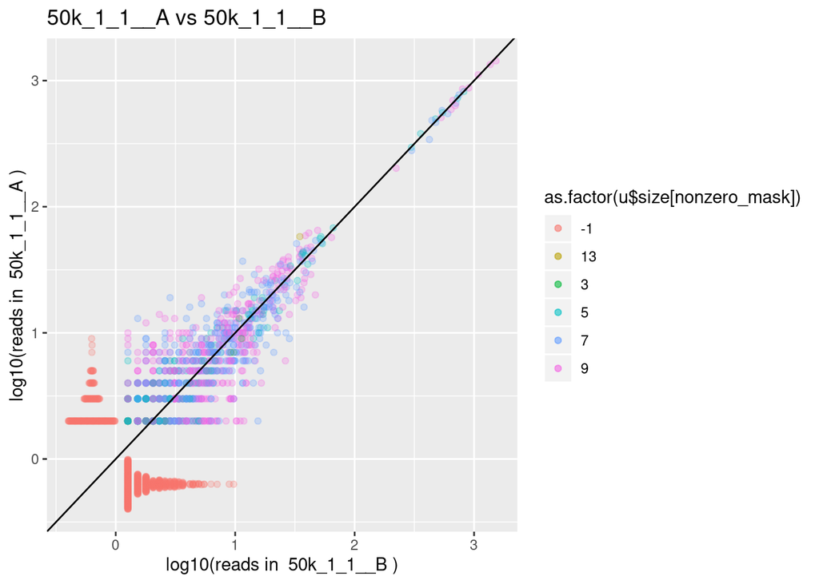

```r
loxcoder::pair_comparison_plot(loxcoder::sample(x_50k, '50k_1_1__A'),
                                     loxcoder::sample(x_50k, '50k_1_1__B'), dist_range = c(0, 15))
```

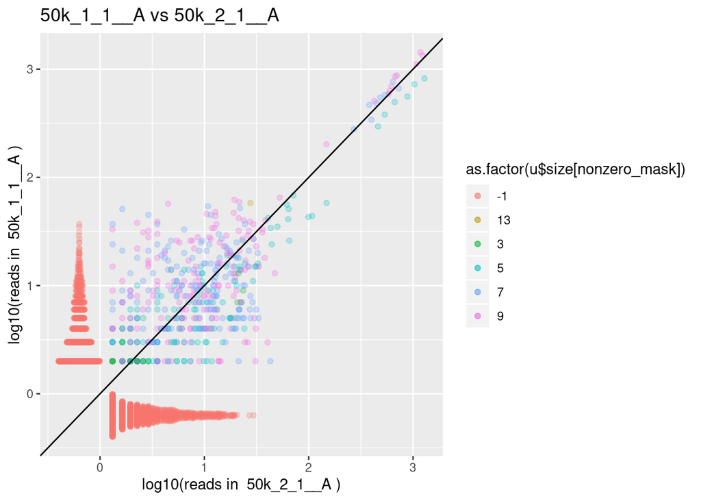

```r
loxcoder::pair_comparison_plot(loxcoder::sample(x_50k, '50k_1_1__A'),
                                     loxcoder::sample(x_50k, '50k_2_1__A'), dist_range = c(0, 15))
```

To further investigate, we can plot the distribution of barcode sizes (both valid and invalid) and recombination distances (for barcodes of size 9).

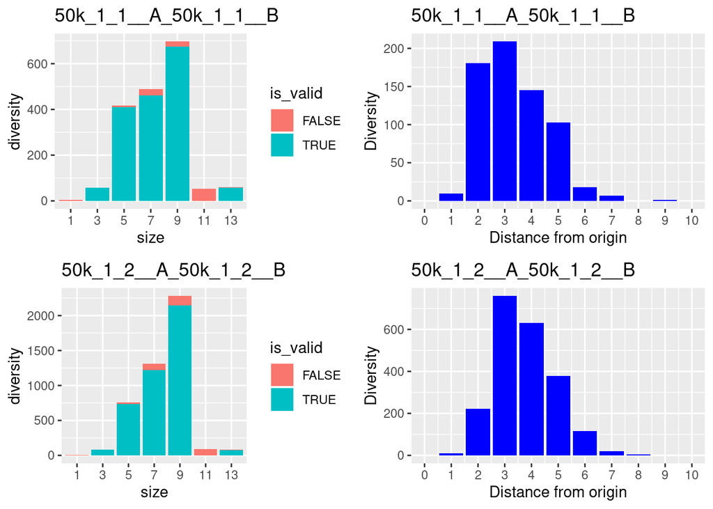

```r
grid.arrange(loxcoder::size_plot(loxcoder::sample(x_merged, 'samp_1_pulse_1')),
             loxcoder::dist_orig_plot(loxcoder::sample(x_merged, 'samp_1_pulse_1'), size = 9),
             loxcoder::size_plot(loxcoder::sample(x_merged, 'samp_1_pulse_2')),
             loxcoder::dist_orig_plot(loxcoder::sample(x_merged, 'samp_1_pulse_2'), size = 9))
```